# Time Series: A First Course with Bootstrap Starter

# Lesson 12-5: Sieve Bootstraps

- We now investigate two transformations $\Pi$: the AR sieve and the MA sieve.

## Paradigm 12.5.2. Sieves

- Consider the case that the transformation $\Pi$ involves infinitely many parameters.
- So we consider a sequence of transformations $\Pi_1, \Pi_2, \ldots$, where $\Pi_j$ has $j$ parameters.
- We suppose these transformations to be nested. This means that $\Pi_j$ is obtained from $\Pi_{j+1}$ by restricting the $j+1$th parameter to some constant value (such as zero).
- Also we suppose that taking the limit of these transformations gives $\Pi$.
- Such a collection is called a *sieve*.
- The *method of sieves* is to apply $\Pi_m$ to the sample $X_1, \ldots, X_n$, with $m$ chosen large enough that $\Pi_m \approx \Pi$, while also $m$ is small enough that we can estimate all the parameters.
- If we get additional data ($n$ increases), then we would also increase $m$.

## Paradigm 12.5.4. Autoregressive Sieve and the AR Sieve Bootstrap

- Suppose we have an AR($\infty$) process:
  $$\Xi (B) X_t = \epsilon_t \sim \mbox{i.i.d.} G.$$
- We take $\Pi_p$ to be an AR($p$) model. This is called the *AR sieve*.
- Notation:
  $$\phi^{(p)} (B) = 1 - \sum_{j=1}^p \phi_j^{(p)} B^j.$$
- So as $p$ increases, all the coefficients can change (and we get more coefficients, too).
- The order $p$ can be linked to sample size $n$ by a formula. Or $p$ can be determined empirically, as a statistic of the sample.
- Once this $\Pi_p$ is determined, we can do an AR($p$) bootstrap (generalizing the $p=1$ case considered in previous notebook).
- Because $p$ grows with $n$, this is called the *AR sieve bootstrap*.

## Example 12.5.6. Lag 12 Autocorrelation of Gasoline Sales

- Consider the seasonally adjusted gasoline sales data.
- Apply logs and differences, obtaining a linear process (this is an assumption).

```r
gassa <- read.table("GasSA_2-11-13.dat")
gassa <- ts(log(gassa),start=1992,frequency=12)
gas.diff <- diff(gassa)
n <- length(gas.diff)
```

- We want to estimate $\rho (12)$, and get the cdf of $\widehat{\rho} (12) - \rho (12)$.
- We use an AR sieve bootstrap with $p=12$ (based on analysis of the PACF plot) for this sample size. There are $M=10^5$ replications, and the pseudo-samples are constructed using a burnin of $500$.

```r
rho.hat <- acf(gas.diff,lag=n-1,type="correlation",plot=FALSE)$acf[,,1]
gas.acf12 <- rho.hat[13]
p.order <- 12
phi.ar <- solve(toeplitz(rho.hat[1:p.order])) %*% rho.hat[2:(p.order+1)]

gas.resids <- gas.diff[(p.order+1):n]
for(i in 1:p.order) { gas.resids <- gas.resids - phi.ar[i]*gas.diff[(p.order+1-i):(n-i)] }
gas.resids <- gas.resids - mean(gas.resids)
gas.edf <- sort(gas.resids)

monte.roots <- NULL
burnin <- 500
Monte <- 100000
for(i in 1:Monte)
{
    monte.resids <- sample(gas.edf,size=n+burnin,replace=TRUE)
    init.value <- rep(0,p.order)
    monte.sample <- filter(monte.resids,phi.ar,method="recursive",init=init.value)[(burnin+1):(burnin+n)]
    monte.root <- acf(monte.sample,lag=n-1,plot=FALSE)$acf[,,1][13] - gas.acf12
    monte.roots <- c(monte.roots,monte.root)
}
# hist(monte.roots)
interval <- c(sort(monte.roots)[floor(.025*Monte)],sort(monte.roots)[floor(.975*Monte)])
```

- The lag 12 autocorrelation is estimated to be -0.239469.
- The $95 \%$ confidence interval based on the bootstrap is [-0.3857244,-0.1232644].
- We plot the bootstrap edf.

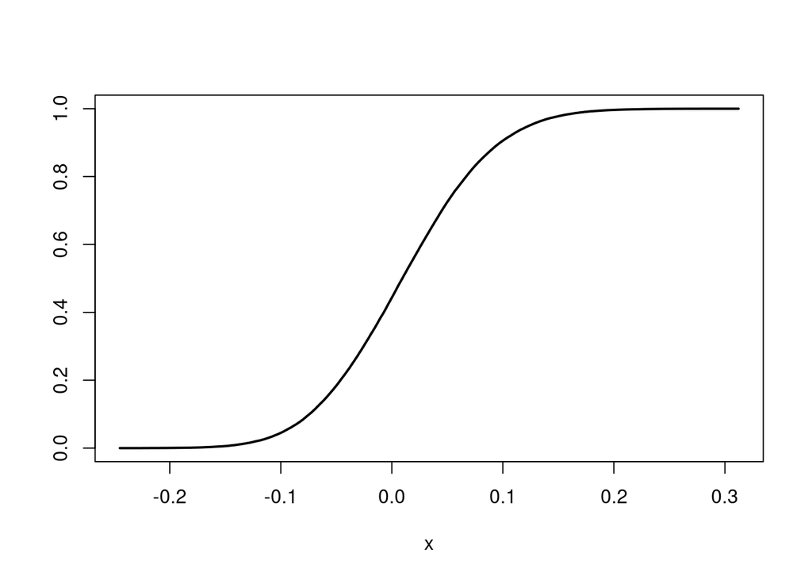

```r
plot(sort(monte.roots),seq(1,Monte)/Monte,type="l",xlab="x",ylab="",lwd=2)
```

## Paradigm 12.5.8. Linear Process Bootstrap

- Consider a stationary process $\{ Y_t \}$ with mean $\mu$ and acvf $\gamma (h)$.
- For a sample of size $n$, we have $\Gamma_n$ is the Toeplitz covariance matrix of the sample. Recall that $\Gamma_n = { \{ \gamma (j-k) \}}$.
- We can taper the sample autocovariance estimators in order to estimate the whole matrix:
  $$\breve{\gamma} (h) = \Lambda (h/d) \widehat{\gamma} (h).$$
- Here $\Lambda$ is a *taper*, which is a symmetric function on $[-1,1]$ with non-negative values, which down-weights $\widehat{\gamma}$ when $|h|$ is large.
- Also $d$ is the *bandwidth*, which is chosen by the user, and typically satisfies $d/n \rightarrow 0$.
- For example, $\Lambda$ can be a trapezoid function.
- Then we construct $\breve{\Gamma}_n$ by inserting $\breve{\gamma} (h)$ for $\gamma (h)$, and ensuring the matrix is positive-definite.
- There is a Cholesky decomposition of the matrix, of the form
  $$\breve{\Gamma} = L \, D \, L^{\prime},$$
  where $L$ is unit lower-triangular and $D$ is diagonal with positive entries.
- Then we can transform the data to residuals by first subtracting the sample mean, and then multiplying the sample vector by $D^{-1/2} L^{-1}$.
- To the resulting residuals we apply the i.i.d. bootstrap; this whole procedure is called the *Linear process bootstrap*.
- When using a trapezoidal taper, $\breve{\gamma} (h) = 0$ if $|h| > d$, so we can think of these autocovariance estimates as corresponding to an MA($d$) process.
- If we use some taper such that $\breve{\gamma} (h)$ truncates at $h = q$, the structure resembles that of an MA($q$) process, and the resulting procedure is called the *MA sieve bootstrap*.

## Example 12.5.11. Lag 1 Autocovariance of Non-Defense Capitalization

- Consider the Non-Defense Capitalization time series.
- After differencing, we wish to estimate $\gamma (1)$ and compute the cdf $\zeta = {\mathbb P} [ \widehat{\gamma} (1) - \gamma (1) \leq x]$.

```r
ndc <- read.table("Nondefcap.dat")
ndc <- ts(ndc[,2],start=c(1992,3),frequency=12,names= "NewOrders")
ndc.diff <- diff(ndc)
n <- length(ndc.diff)
```

- We use an MA sieve bootstrap with the truncation taper and $q=10$ for this sample size. There are $M=10^5$ replications.

```r
gamma.hat <- acf(ndc.diff,lag=n-1,type="covariance",plot=FALSE)$acf[,,1]
ndc.acf1 <- gamma.hat[2]
q.order <- 10
gamma.mat <- toeplitz(c(gamma.hat[1:(q.order+1)],rep(0,n-(q.order+1))))

gamma.chol <- t(chol(gamma.mat))
ndc.resids <- solve(gamma.chol,ndc.diff)
ndc.resids <- ndc.resids - mean(ndc.resids)
ndc.edf <- sort(ndc.resids)

monte.roots <- NULL
Monte <- 100000
for(i in 1:Monte)
{
    monte.resids <- sample(ndc.edf,size=n,replace=TRUE)
    monte.sample <- gamma.chol %*% monte.resids
    monte.root <- acf(monte.sample,lag=n-1,plot=FALSE,type="covariance")$acf[,,1][2] - ndc.acf1
    monte.roots <- c(monte.roots,monte.root)
}
# hist(monte.roots)
interval <- c(sort(monte.roots)[floor(.025*Monte)],sort(monte.roots)[floor(.975*Monte)])
```

- The lag 1 autocovariance is estimated to be -0.002489.
- The $95 \%$ confidence interval based on the bootstrap is [-0.0034995,-0.0010886].
- We plot the bootstrap edf.

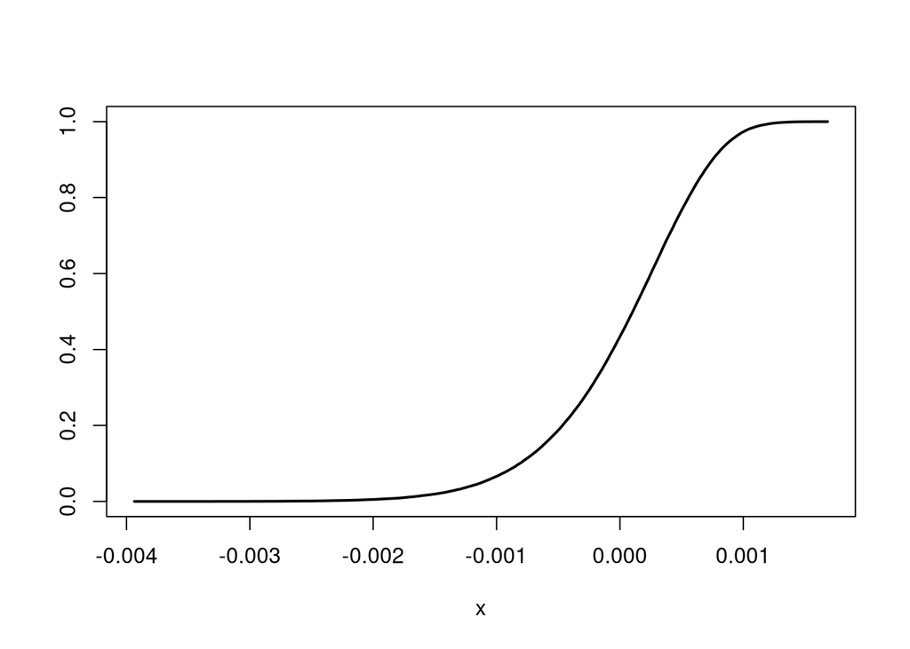

```r
plot(sort(monte.roots),seq(1,Monte)/Monte,type="l",xlab="x",ylab="",lwd=2)
```